# Project: Wrangle and Analyze Data : WeRateDogs Twitter Data

- Introduction
- Part I - Gathering data
- Part II - Assessing data
- Part III - Cleaning data
- Analysis

### Introduction

The dataset that you will be wrangling (and analyzing and visualizing) is the tweet archive of Twitter user @dog_rates, also known as WeRateDogs. WeRateDogs is a Twitter account that rates people's dogs with a humorous comment about the dog. These ratings almost always have a denominator of 10. The numerators, though? Almost always greater than 10. 11/10, 12/10, 13/10, etc. Why? Because "they're good dogs Brent." WeRateDogs has over 4 million followers and has received international media coverage.

#### Part I - Gathering data

To get started, Loading Data

```python
import pandas as pd
import numpy as np
import requests
import tweepy
import json
import re
import matplotlib.pyplot as plt
import warnings
import os
import time
```

- The Twitter archive

```python
#read twitter archive data
twit_arch = pd.read_csv('twitter-archive-enhanced-2.csv', sep=',')
```

- The tweet image predictions i.e., what breed of dog (or other object, animal, etc.) is present in each tweet according to a neural network. This file (image_predictions.tsv) is hosted on Udacity's servers and should be downloaded programmatically using the Requests library and the following URL: https://d17h27t6h515a5.cloudfront.net/topher/2017/August/599fd2ad_image-predictions/image-predictions.tsv

```python
# Downloading and saving data using Requests
url = 'https://d17h27t6h515a5.cloudfront.net/topher/2017/August/599fd2ad_image-predictions/image-predictions.tsv'
image_predictions = requests.get(url)
open('image_predictions.tsv', 'wb').write(image_predictions.content)
```

```
335079
```

```python
#read Image prediction data
image_pred = pd.read_csv('image_predictions.tsv', sep = '\t')
```

Let's clarify the use of the Twitter API because we applied for a Twitter developer account and were rejected. For clarity, we used the Python transcript that was given by Udacity

```python
#Twitter_api.py
import tweepy
from tweepy import OAuthHandler
import json
from timeit import default_timer as timer

# Query Twitter API for each tweet in the Twitter archive and save JSON in a text file
# These are hidden to comply with Twitter's API terms and conditions
consumer_key = 'HIDDEN'
consumer_secret = 'HIDDEN'
access_token = 'HIDDEN'
access_secret = 'HIDDEN'

auth = OAuthHandler(consumer_key, consumer_secret)
auth.set_access_token(access_token, access_secret)

api = tweepy.API(auth, wait_on_rate_limit=True)

# NOTE TO STUDENT WITH MOBILE VERIFICATION ISSUES:
# df_1 is a DataFrame with the twitter_archive_enhanced.csv file. You may have to
# change line 17 to match the name of your DataFrame with twitter_archive_enhanced.csv
# NOTE TO REVIEWER: this student had mobile verification issues so the following
# Twitter API code was sent to this student from a Udacity instructor
# Tweet IDs for which to gather additional data via Twitter's API
tweet_ids = twit_arch.tweet_id.values
len(tweet_ids)

# Query Twitter's API for JSON data for each tweet ID in the Twitter archive
count = 0
fails_dict = {}
start = timer()
# Save each tweet's returned JSON as a new line in a .txt file
with open('tweet-json.txt', 'w') as outfile:
    # This loop will likely take 20-30 minutes to run because of Twitter's rate limit
    for tweet_id in tweet_ids:
        count += 1
        print(str(count) + ": " + str(tweet_id))
        try:
            tweet = api.get_status(tweet_id, tweet_mode='extended')
            print("Success")
            json.dump(tweet._json, outfile)
            outfile.write('\n')
        except tweepy.TweepError as e:
            print("Fail")
            fails_dict[tweet_id] = e
            pass
end = timer()
print(end - start)
print(fails_dict)
```

[output not shown]

[output cut: 4659 more lines]

[output not shown]

Each tweet's retweet count and favorite ("like") count at minimum, Each tweet's JSON data. Lets read this tweet_json.txt file line by line into a pandas DataFrame with (at minimum) tweet ID, retweet count, and favorite count.

- twitter_api.py: This is the Twitter API code to gather some of the required data for the project. Read the code and comments, understand how the code works, then copy and paste it into your notebook.
- tweet_json.txt: This is the resulting data from twitter_api.py. You can proceed with the following part of "Gathering Data for this Project"

```python
# For loop to append each tweet into a list
tweets_data = []

tweet_file = open('tweet_json.txt', "r")

for line in tweet_file:
    try:
        tweet = json.loads(line)
        tweets_data.append(tweet)
    except:
        continue

tweet_file.close()
```

Lets read this tweet_json.txt file line by line into a pandas DataFrame with (at minimum) tweet ID, retweet count, and favorite count."

```python
twet_df = pd.DataFrame()
```

```python
# Add selected variables to tweet_info DataFrame
twet_df['tweet_id'] = list(map(lambda tweet: tweet['id'], tweets_data))
twet_df['retweet_count'] = list(map(lambda tweet: tweet['retweet_count'], tweets_data))
twet_df['favorite_count'] = list(map(lambda tweet: tweet['favorite_count'], tweets_data))
```

```python
twet_df.info()
```

```
<class 'pandas.core.frame.DataFrame'>
RangeIndex: 2350 entries, 0 to 2349
Data columns (total 3 columns):
 #   Column          Non-Null Count  Dtype
---  ------          --------------  -----
 0   tweet_id        2350 non-null   int64
 1   retweet_count   2350 non-null   int64
 2   favorite_count  2350 non-null   int64
dtypes: int64(3)
memory usage: 55.2 KB
```

#### Part II - Assessing Data: Quality and Tidiness Issues

```python
twit_arch.sample(15)
```

|  | tweet_id | in_reply_to_status_id | in_reply_to_user_id | timestamp | source | text | retweeted_status_id | retweeted_status_user_id | retweeted_status_timestamp | expanded_urls | rating_numerator | rating_denominator | name | doggo | floofer | pupper | puppo |
| --- | --- | --- | --- | --- | --- | --- | --- | --- | --- | --- | --- | --- | --- | --- | --- | --- | --- |
| 330 | 833124694597443584 | NaN | NaN | 2017-02-19 01:23:00 +0000 | <a href="http://twitter.com/download/iphone" r... | This is Gidget. She's a spy pupper. Stealthy a... | NaN | NaN | NaN | https://twitter.com/dog_rates/status/833124694... | 12 | 10 | Gidget | None | None | pupper | None |
| 1706 | 680805554198020098 | NaN | NaN | 2015-12-26 17:41:07 +0000 | <a href="http://vine.co" rel="nofollow">Vine -... | This guy's dog broke. So sad. 9/10 would still... | NaN | NaN | NaN | https://vine.co/v/iAP0Ugzi2PO | 9 | 10 | None | None | None | None | None |
| 1777 | 677918531514703872 | NaN | NaN | 2015-12-18 18:29:07 +0000 | <a href="http://twitter.com/download/iphone" r... | "Everything looks pretty good in there. Make s... | NaN | NaN | NaN | https://twitter.com/dog_rates/status/677918531... | 10 | 10 | None | None | None | None | None |
| 753 | 778774459159379968 | NaN | NaN | 2016-09-22 01:54:34 +0000 | <a href="http://twitter.com/download/iphone" r... | RT @dog_rates: In case you haven't seen the mo... | 7.580996e+17 | 4.196984e+09 | 2016-07-27 00:40:12 +0000 | https://vine.co/v/hQJbaj1VpIz,https://vine.co/... | 13 | 10 | None | None | None | None | None |
| 808 | 771770456517009408 | NaN | NaN | 2016-09-02 18:03:10 +0000 | <a href="http://twitter.com/download/iphone" r... | This is Davey. He'll have your daughter home b... | NaN | NaN | NaN | https://twitter.com/dog_rates/status/771770456... | 11 | 10 | Davey | None | None | None | None |
| 39 | 884876753390489601 | NaN | NaN | 2017-07-11 20:47:12 +0000 | <a href="http://twitter.com/download/iphone" r... | This is Lola. It's her first time outside. Mus... | NaN | NaN | NaN | https://twitter.com/dog_rates/status/884876753... | 13 | 10 | Lola | None | None | None | None |
| 987 | 749036806121881602 | NaN | NaN | 2016-07-02 00:27:45 +0000 | <a href="http://twitter.com/download/iphone" r... | This is Dietrich. He hops at random. Other dog... | NaN | NaN | NaN | https://twitter.com/dog_rates/status/749036806... | 8 | 10 | Dietrich | None | None | None | None |
| 1138 | 728035342121635841 | NaN | NaN | 2016-05-05 01:35:26 +0000 | <a href="http://twitter.com/download/iphone" r... | This is all I want in my life. 12/10 for super... | NaN | NaN | NaN | https://twitter.com/dog_rates/status/728035342... | 12 | 10 | all | None | None | pupper | None |
| 1817 | 676603393314578432 | NaN | NaN | 2015-12-15 03:23:14 +0000 | <a href="http://twitter.com/download/iphone" r... | This is Godzilla pupper. He had a ruff childho... | NaN | NaN | NaN | https://twitter.com/dog_rates/status/676603393... | 9 | 10 | Godzilla | None | None | pupper | None |
| 1888 | 674781762103414784 | NaN | NaN | 2015-12-10 02:44:43 +0000 | <a href="http://twitter.com/download/iphone" r... | Bedazzled pup here. Fashionable af. Super yell... | NaN | NaN | NaN | https://twitter.com/dog_rates/status/674781762... | 8 | 10 | None | None | None | None | None |
| 1443 | 696744641916489729 | NaN | NaN | 2016-02-08 17:17:22 +0000 | <a href="http://vine.co" rel="nofollow">Vine -... | This is Klevin. He doesn't want his family bra... | NaN | NaN | NaN | https://vine.co/v/i1wrljBUjAu | 10 | 10 | Klevin | None | None | None | None |
| 1294 | 707995814724026368 | NaN | NaN | 2016-03-10 18:25:30 +0000 | <a href="http://twitter.com/download/iphone" r... | This is Farfle. He lost his back legs during t... | NaN | NaN | NaN | https://twitter.com/dog_rates/status/707995814... | 12 | 10 | Farfle | None | None | None | None |
| 772 | 776477788987613185 | NaN | NaN | 2016-09-15 17:48:25 +0000 | <a href="http://twitter.com/download/iphone" r... | This is Huck. He's addicted to caffeine. Hope ... | NaN | NaN | NaN | https://twitter.com/dog_rates/status/776477788... | 11 | 10 | Huck | None | None | pupper | None |
| 1911 | 674410619106390016 | NaN | NaN | 2015-12-09 02:09:56 +0000 | <a href="http://twitter.com/download/iphone" r... | This is Lenny. He wants to be a sprinkler. 10/... | NaN | NaN | NaN | https://twitter.com/dog_rates/status/674410619... | 10 | 10 | Lenny | None | None | None | None |
| 566 | 802247111496568832 | NaN | NaN | 2016-11-25 20:26:31 +0000 | <a href="http://twitter.com/download/iphone" r... | RT @dog_rates: Everybody drop what you're doin... | 7.790561e+17 | 4.196984e+09 | 2016-09-22 20:33:42 +0000 | https://twitter.com/dog_rates/status/779056095... | 13 | 10 | None | None | None | None | None |

```python
twit_arch.info()
```

```
<class 'pandas.core.frame.DataFrame'>
RangeIndex: 2356 entries, 0 to 2355
Data columns (total 17 columns):
 #   Column                      Non-Null Count  Dtype
---  ------                      --------------  -----
 0   tweet_id                    2356 non-null   int64
 1   in_reply_to_status_id       78 non-null     float64
 2   in_reply_to_user_id         78 non-null     float64
 3   timestamp                   2356 non-null   object
 4   source                      2356 non-null   object
 5   text                        2356 non-null   object
 6   retweeted_status_id         181 non-null    float64
 7   retweeted_status_user_id    181 non-null    float64
 8   retweeted_status_timestamp  181 non-null    object
 9   expanded_urls               2297 non-null   object
 10  rating_numerator            2356 non-null   int64
 11  rating_denominator          2356 non-null   int64
 12  name                        2356 non-null   object
 13  doggo                       2356 non-null   object
 14  floofer                     2356 non-null   object
 15  pupper                      2356 non-null   object
 16  puppo                       2356 non-null   object
dtypes: float64(4), int64(3), object(10)
memory usage: 313.0+ KB
```

```python
twit_arch.doggo.value_counts()
```

```
None     2259
doggo      97
Name: doggo, dtype: int64
```

```python
image_pred.sample(15)
```

|  | tweet_id | jpg_url | img_num | p1 | p1_conf | p1_dog | p2 | p2_conf | p2_dog | p3 | p3_conf | p3_dog |
| --- | --- | --- | --- | --- | --- | --- | --- | --- | --- | --- | --- | --- |
| 199 | 669661792646373376 | https://pbs.twimg.com/media/CUsd2TfWwAAmdjb.jpg | 1 | weasel | 0.262802 | False | Siamese_cat | 0.148263 | False | hamster | 0.116374 | False |
| 2031 | 883117836046086144 | https://pbs.twimg.com/media/DEF2-_hXoAAs62q.jpg | 2 | golden_retriever | 0.949562 | True | Labrador_retriever | 0.045948 | True | kuvasz | 0.002471 | True |
| 2071 | 891689557279858688 | https://pbs.twimg.com/media/DF_q7IAWsAEuuN8.jpg | 1 | paper_towel | 0.170278 | False | Labrador_retriever | 0.168086 | True | spatula | 0.040836 | False |
| 2003 | 877201837425926144 | https://pbs.twimg.com/media/DCxyahJWsAAddSC.jpg | 1 | Pembroke | 0.931120 | True | Cardigan | 0.068698 | True | basenji | 0.000082 | True |
| 1280 | 750132105863102464 | https://pbs.twimg.com/media/CmkBKuwWgAAamOI.jpg | 1 | toy_poodle | 0.478018 | True | miniature_poodle | 0.207458 | True | croquet_ball | 0.085879 | False |
| 133 | 668480044826800133 | https://pbs.twimg.com/media/CUbrDWOWcAEyMdM.jpg | 1 | Arctic_fox | 0.119243 | False | Labrador_retriever | 0.099965 | True | pug | 0.086717 | True |
| 876 | 698262614669991936 | https://pbs.twimg.com/media/CbC6JL_WEAI_PhH.jpg | 1 | Italian_greyhound | 0.107948 | True | basset | 0.075230 | True | Staffordshire_bullterrier | 0.069436 | True |
| 1152 | 732585889486888962 | https://pbs.twimg.com/media/Ciqq-VFUUAANlWm.jpg | 2 | Staffordshire_bullterrier | 0.843359 | True | American_Staffordshire_terrier | 0.028290 | True | miniature_pinscher | 0.016793 | True |
| 1083 | 718460005985447936 | https://pbs.twimg.com/media/Cfh7j6CWQAAndTd.jpg | 1 | badger | 0.356946 | False | Boston_bull | 0.252781 | True | kelpie | 0.113433 | True |
| 667 | 682962037429899265 | https://pbs.twimg.com/media/CXpeVzQW8AApKYb.jpg | 1 | dingo | 0.278600 | False | Chihuahua | 0.155207 | True | loupe | 0.153598 | False |
| 1661 | 811744202451197953 | https://pbs.twimg.com/media/C0PlCQjXAAA9TIh.jpg | 1 | Pekinese | 0.386082 | True | Labrador_retriever | 0.202862 | True | golden_retriever | 0.170487 | True |
| 614 | 680161097740095489 | https://pbs.twimg.com/media/CXBq6RPWkAAaNuU.jpg | 1 | bluetick | 0.268681 | True | miniature_pinscher | 0.125652 | True | English_setter | 0.089373 | True |
| 354 | 672591762242805761 | https://pbs.twimg.com/media/CVWGotpXAAMRfGq.jpg | 1 | kuvasz | 0.777659 | True | Great_Pyrenees | 0.112517 | True | golden_retriever | 0.038351 | True |
| 641 | 681320187870711809 | https://pbs.twimg.com/media/CXSJGAQUQAAoG9Q.jpg | 1 | Samoyed | 0.362596 | True | Eskimo_dog | 0.245395 | True | Siberian_husky | 0.108232 | True |
| 1354 | 760252756032651264 | https://pbs.twimg.com/media/Coz12OLWgAADdys.jpg | 1 | radio_telescope | 0.155279 | False | dam | 0.154515 | False | crane | 0.098040 | False |

```python
image_pred.info()
```

```
<class 'pandas.core.frame.DataFrame'>
RangeIndex: 2075 entries, 0 to 2074
Data columns (total 12 columns):
 #   Column    Non-Null Count  Dtype
---  ------    --------------  -----
 0   tweet_id  2075 non-null   int64
 1   jpg_url   2075 non-null   object
 2   img_num   2075 non-null   int64
 3   p1        2075 non-null   object
 4   p1_conf   2075 non-null   float64
 5   p1_dog    2075 non-null   bool
 6   p2        2075 non-null   object
 7   p2_conf   2075 non-null   float64
 8   p2_dog    2075 non-null   bool
 9   p3        2075 non-null   object
 10  p3_conf   2075 non-null   float64
 11  p3_dog    2075 non-null   bool
dtypes: bool(3), float64(3), int64(2), object(4)
memory usage: 152.1+ KB
```

```python
image_pred.p1_dog.value_counts()
```

```
True     1532
False     543
Name: p1_dog, dtype: int64
```

```python
image_pred.describe()
```

|  | tweet_id | img_num | p1_conf | p2_conf | p3_conf |
| --- | --- | --- | --- | --- | --- |
| count | 2.075000e+03 | 2075.000000 | 2075.000000 | 2.075000e+03 | 2.075000e+03 |
| mean | 7.384514e+17 | 1.203855 | 0.594548 | 1.345886e-01 | 6.032417e-02 |
| std | 6.785203e+16 | 0.561875 | 0.271174 | 1.006657e-01 | 5.090593e-02 |
| min | 6.660209e+17 | 1.000000 | 0.044333 | 1.011300e-08 | 1.740170e-10 |
| 25% | 6.764835e+17 | 1.000000 | 0.364412 | 5.388625e-02 | 1.622240e-02 |
| 50% | 7.119988e+17 | 1.000000 | 0.588230 | 1.181810e-01 | 4.944380e-02 |
| 75% | 7.932034e+17 | 1.000000 | 0.843855 | 1.955655e-01 | 9.180755e-02 |
| max | 8.924206e+17 | 4.000000 | 1.000000 | 4.880140e-01 | 2.734190e-01 |

```python
twet_df.info()
```

```
<class 'pandas.core.frame.DataFrame'>
RangeIndex: 2350 entries, 0 to 2349
Data columns (total 3 columns):
 #   Column          Non-Null Count  Dtype
---  ------          --------------  -----
 0   tweet_id        2350 non-null   int64
 1   retweet_count   2350 non-null   int64
 2   favorite_count  2350 non-null   int64
dtypes: int64(3)
memory usage: 55.2 KB
```

#### Quality

##### `twit_arch` table

- 1 - The timestamp field is in string format (object)
- 2 - Some of the rows have invalid strings in the name column, e.g. "a", "an", "in".
- 3 - Nan value in the name column.
- 4 - There are some tweets beyond August 1st, 2017.
- 5 - Erroneous data types in the source column are not consistent..html code
- 6 - Dataset contains retweets.
- 7 - Extra characters after '&'.

##### `image_pred` table

- 8 - image prediction shows that has three level of confidence and some image is not images of dogs.

#### Tidiness

- 1 - `image_pred` should be part of the `twit_arch` table.
- 2 - `twet_df` should be part of the `twit_arch` table as well.
- 3 - doggo, floofer, pupper, puppo columns in `twit_arch` should be combined into a single column as this is one variable that identify stage of dog.

#### Part III - Cleaning data

```python
#Make a copy of twit_arch
clean_df= twit_arch.copy()
```

```python
#Make a copy of image_pred
image_pred_copy = image_pred.copy()
```

```python
#Make a copy of twet_df
twet_df_copy = twet_df.copy()
```

#### Tidiness #1:

`image_pred` should be part of the `twit_arch` table

##### Define

Merge `image_pred` with `twit_arch` table on 'tweet_id'

##### Code

```python
clean_df = pd.merge(clean_df, image_pred_copy, on=['tweet_id'], how='left')
```

##### Test

```python
list(clean_df.columns)
```

```
['tweet_id',
 'in_reply_to_status_id',
 'in_reply_to_user_id',
 'timestamp',
 'source',
 'text',
 'retweeted_status_id',
 'retweeted_status_user_id',
 'retweeted_status_timestamp',
 'expanded_urls',
 'rating_numerator',
 'rating_denominator',
 'name',
 'doggo',
 'floofer',
 'pupper',
 'puppo',
 'jpg_url',
 'img_num',
 'p1',
 'p1_conf',
 'p1_dog',
 'p2',
 'p2_conf',
 'p2_dog',
 'p3',
 'p3_conf',
 'p3_dog']
```

#### Tidiness #2:

`twet_df` should be part of the `twit_arch` table as well

##### Define

Merge `twet_df` with `twit_arch` table on 'tweet_id'

##### Code

```python
clean_df = pd.merge(clean_df, twet_df_copy,
                    on=['tweet_id'], how='left')
```

##### Test

```python
clean_df.info()
```

```
<class 'pandas.core.frame.DataFrame'>
Int64Index: 2356 entries, 0 to 2355
Data columns (total 30 columns):
 #   Column                      Non-Null Count  Dtype
---  ------                      --------------  -----
 0   tweet_id                    2356 non-null   int64
 1   in_reply_to_status_id       78 non-null     float64
 2   in_reply_to_user_id         78 non-null     float64
 3   timestamp                   2356 non-null   object
 4   source                      2356 non-null   object
 5   text                        2356 non-null   object
 6   retweeted_status_id         181 non-null    float64
 7   retweeted_status_user_id    181 non-null    float64
 8   retweeted_status_timestamp  181 non-null    object
 9   expanded_urls               2297 non-null   object
```

[output cut: 22 more lines]

#### Quality # 2:

Some of the rows have invalid strings in the name column, e.g. "a", "an", "in".

##### Define

Replace all no valid words in the name column with the string "none"

##### Code

```python
#Create a mask
names_mask = clean_df.name.str.contains('^[a-z]', regex = True)
clean_df[names_mask].name.value_counts().sort_index()
```

```
a               55
actually         2
all              1
an               7
by               1
getting          2
his              1
incredibly       1
infuriating      1
just             4
life             1
light            1
mad              2
my               1
not              2
officially       1
old              1
one              4
quite            4
space            1
such             1
the              8
this             1
unacceptable     1
very             5
Name: name, dtype: int64
```

```python
# rename no valid words with None name
clean_df.loc[names_mask, 'name'] = "None"
```

##### Test

```python
clean_df[names_mask].name.value_counts().sort_index()
```

```
None    109
Name: name, dtype: int64
```

#### Quality #5:

Erroneous data types in the source column are not consistent..html code

##### Define

Extract the string in the script

##### Code

```python
clean_df['source'] = clean_df['source'].str.extract('^<a.+>(.+)</a>$')
```

##### Test

```python
clean_df.source.value_counts()
```

```
Twitter for iPhone     2221
Vine - Make a Scene      91
Twitter Web Client       33
TweetDeck                11
Name: source, dtype: int64
```

#### Quality #1:

The timestamp field is in string format (object)

##### Define

Convert timestamp to datetime data type.

##### Code

```python
clean_df['timestamp'] = pd.to_datetime(clean_df.timestamp)
```

##### Test

```python
clean_df.info()
```

```
<class 'pandas.core.frame.DataFrame'>
Int64Index: 2356 entries, 0 to 2355
Data columns (total 30 columns):
 #   Column                      Non-Null Count  Dtype
---  ------                      --------------  -----
 0   tweet_id                    2356 non-null   int64
 1   in_reply_to_status_id       78 non-null     float64
 2   in_reply_to_user_id         78 non-null     float64
 3   timestamp                   2356 non-null   datetime64[ns, UTC]
 4   source                      2356 non-null   object
 5   text                        2356 non-null   object
 6   retweeted_status_id         181 non-null    float64
 7   retweeted_status_user_id    181 non-null    float64
 8   retweeted_status_timestamp  181 non-null    object
 9   expanded_urls               2297 non-null   object
```

[output cut: 22 more lines]

#### Quality #4:

There are some tweets beyond August 1st, 2017.

##### Define

Drop all tweets beyond August 1st, 2017.

##### Code

```python
ts = '2017-08-01 00:00:00'
clean_df = clean_df[(clean_df['timestamp'] < ts)]
```

##### Test

```python
(clean_df['timestamp'] > ts).value_counts()
```

```
False    2354
Name: timestamp, dtype: int64
```

#### Quality #6:

Dataset contains retweets.

##### Define

Remove retweets.

##### Code

```python
# Select rows where 'retweeted_status_id' is null to save to clean_df
clean_df = clean_df[clean_df['retweeted_status_id'].isnull()]
```

##### Test

```python
clean_df.shape
```

```
(2173, 30)
```

#### Quality #8:

image prediction shows that has three level of confidence and some image is not images of dogs.

##### Define

Setup the conditions for selection \ Set the choice order based on the selection conditions for predicted breed, and\ Set the choice order for confidence level based on the selection conditions\ Select the predicted breed based on the first successful condition.\ Select the predicted confidence level based on the first successful condition & Set breed as 'none' and confidence to 0 for any cases where all 3 prediction flags are False.

##### Code

```python
# setup the conditions for selection
conditions = [(clean_df['p1_dog'] == True), (clean_df['p2_dog'] == True), (clean_df['p3_dog'] == True)]
```

```python
# set the choice order based on the selection conditions for predicted breed
choices_breed = [clean_df['p1'],clean_df['p2'],clean_df['p3']]
```

```python
# set the choice order for confidence level based on the selection conditions
choices_confidence = [clean_df['p1_conf'], clean_df['p2_conf'], clean_df['p3_conf']]
```

```python
# select the predicted breed based on the first successful condition
clean_df['breed'] = np.select(conditions, choices_breed, default = 'none')
```

```python
# select the predicted confidence level based on the first successful condition
clean_df['confidence'] = np.select(conditions, choices_confidence, default = 0)
```

##### Test

```python
clean_df.head()
```

|  | tweet_id | in_reply_to_status_id | in_reply_to_user_id | timestamp | source | text | retweeted_status_id | retweeted_status_user_id | retweeted_status_timestamp | expanded_urls | ... | p2 | p2_conf | p2_dog | p3 | p3_conf | p3_dog | retweet_count | favorite_count | breed | confidence |
| --- | --- | --- | --- | --- | --- | --- | --- | --- | --- | --- | --- | --- | --- | --- | --- | --- | --- | --- | --- | --- | --- |
| 2 | 891815181378084864 | NaN | NaN | 2017-07-31 00:18:03+00:00 | Twitter for iPhone | This is Archie. He is a rare Norwegian Pouncin... | NaN | NaN | NaN | https://twitter.com/dog_rates/status/891815181... | ... | malamute | 0.078253 | True | kelpie | 0.031379 | True | 4273.0 | 25394.0 | Chihuahua | 0.716012 |
| 3 | 891689557279858688 | NaN | NaN | 2017-07-30 15:58:51+00:00 | Twitter for iPhone | This is Darla. She commenced a snooze mid meal... | NaN | NaN | NaN | https://twitter.com/dog_rates/status/891689557... | ... | Labrador_retriever | 0.168086 | True | spatula | 0.040836 | False | 8884.0 | 42743.0 | Labrador_retriever | 0.168086 |
| 4 | 891327558926688256 | NaN | NaN | 2017-07-29 16:00:24+00:00 | Twitter for iPhone | This is Franklin. He would like you to stop ca... | NaN | NaN | NaN | https://twitter.com/dog_rates/status/891327558... | ... | English_springer | 0.225770 | True | German_short-haired_pointer | 0.175219 | True | 9668.0 | 40904.0 | basset | 0.555712 |
| 5 | 891087950875897856 | NaN | NaN | 2017-07-29 00:08:17+00:00 | Twitter for iPhone | Here we have a majestic great white breaching ... | NaN | NaN | NaN | https://twitter.com/dog_rates/status/891087950... | ... | Irish_terrier | 0.116317 | True | Indian_elephant | 0.076902 | False | 3217.0 | 20508.0 | Chesapeake_Bay_retriever | 0.425595 |
| 6 | 890971913173991426 | NaN | NaN | 2017-07-28 16:27:12+00:00 | Twitter for iPhone | Meet Jax. He enjoys ice cream so much he gets ... | NaN | NaN | NaN | https://gofundme.com/ydvmve-surgery-for-jax,ht... | ... | Border_collie | 0.199287 | True | ice_lolly | 0.193548 | False | 2131.0 | 12033.0 | Appenzeller | 0.341703 |

5 rows × 32 columns

#### Quality #3:

Nan value in the name column.

##### Define

Replace with None name

##### Code

```python
# fill nan value with 'None'
clean_df.name.fillna(value='None', inplace= True)
```

##### Test

```python
clean_df.name.count()
```

```
2173
```

#### Quality #7:

Extra characters after '&'.

##### Define

Remove extra characters after '&' in `twit_arch` ['text'].

##### Code

```python
clean_df['text'] = clean_df['text'].str.replace('&amp;', '&')
```

##### Test

```python
clean_df[clean_df.text.str.contains('&amp;')]
```

|  | tweet_id | in_reply_to_status_id | in_reply_to_user_id | timestamp | source | text | retweeted_status_id | retweeted_status_user_id | retweeted_status_timestamp | expanded_urls | ... | p2 | p2_conf | p2_dog | p3 | p3_conf | p3_dog | retweet_count | favorite_count | breed | confidence |
| --- | --- | --- | --- | --- | --- | --- | --- | --- | --- | --- | --- | --- | --- | --- | --- | --- | --- | --- | --- | --- | --- |

0 rows × 32 columns

#### Tidiness #3:

doggo, floofer, pupper, puppo columns in `twit_arch` should be combined into a single column as this is one variable that identify stage of dog.

##### Define

First replace None in stage columns with empty string / Then combine stage columns / Then format entries with multiple dog stages.

##### Code

```python
#First replace None in stage columns with empty string
clean_df.doggo.replace('None', '', inplace=True)
clean_df.floofer.replace('None', '', inplace=True)
clean_df.pupper.replace('None', '', inplace=True)
clean_df.puppo.replace('None', '', inplace=True)
```

```python
#Then combine stage columns
clean_df['stage'] = clean_df.doggo + clean_df.floofer + clean_df.pupper + clean_df.puppo
```

```python
#Then format entries with multiple dog stages
clean_df.loc[clean_df.stage == 'doggopupper', 'stage'] = 'doggo,pupper'
clean_df.loc[clean_df.stage == 'doggopuppo', 'stage'] = 'doggo,puppo'
clean_df.loc[clean_df.stage == 'doggofloofer', 'stage'] = 'doggo,floofer'
```

##### Test

```python
clean_df.stage.value_counts()
```

```
                 1829
pupper            224
doggo              75
puppo              24
doggo,pupper       10
floofer             9
doggo,floofer       1
doggo,puppo         1
Name: stage, dtype: int64
```

#### Quality

Drop all columns that no needs further analysis and visualization in the next section

```python
df= clean_df.drop(['in_reply_to_status_id',
               'in_reply_to_user_id',
              'retweeted_status_id',
              'retweeted_status_user_id',
              'retweeted_status_timestamp',
                   'pupper',
                   'doggo',
                   'floofer',
                   'puppo',
              'img_num',
               'expanded_urls',
              'p1',
               'p1_dog',
              'p1_conf',
              'p2',
              'p2_conf',
               'p2_dog',
              'p3',
              'p3_conf',
              'p3_dog'], axis=1)
```

```python
#store the cleaned data
df.to_csv('twitter_archive_master.csv', index = False)
```

### Analysis

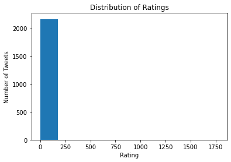

```python
df['rating_numerator'].plot(kind = 'hist')
plt.ylabel('Number of Tweets')
plt.xlabel('Rating')
plt.title('Distribution of Ratings')
plt.show();
```

```python
#Percentage of tweets with rating of 10
rating_10 = sum(df.rating_numerator == 10)
rating_10up= sum(df.rating_numerator > 10)
rating_10_perc = round(rating_10 * 100 / df.shape[0])
rating_10up_perc = round(rating_10up * 100 / df.shape[0])
print("Number of tweets with rating 10+:  {}".format(rating_10))
print("Percentage of tweets:                {}%".format(rating_10_perc))

print("Number of tweets with rating more than 10+:  {}".format(rating_10up))
print("Percentage of tweets:                {}%".format(rating_10up_perc))
```

```
Number of tweets with rating 10+:  442
Percentage of tweets:                20%
Number of tweets with rating more than 10+:  1300
Percentage of tweets:                60%
```

```python
df.describe()
```

|  | tweet_id | rating_numerator | rating_denominator | retweet_count | favorite_count | confidence |
| --- | --- | --- | --- | --- | --- | --- |
| count | 2.173000e+03 | 2173.000000 | 2173.000000 | 2173.000000 | 2173.000000 | 2173.000000 |
| mean | 7.369776e+17 | 13.215370 | 10.493327 | 2749.780028 | 8737.728026 | 0.426538 |
| std | 6.735319e+16 | 47.747664 | 7.022299 | 4705.577127 | 12254.529395 | 0.349532 |
| min | 6.660209e+17 | 0.000000 | 0.000000 | 0.000000 | 51.000000 | 0.000000 |
| 25% | 6.768220e+17 | 10.000000 | 10.000000 | 604.000000 | 1900.000000 | 0.033899 |
| 50% | 7.095662e+17 | 11.000000 | 10.000000 | 1331.000000 | 4011.000000 | 0.407016 |
| 75% | 7.892684e+17 | 12.000000 | 10.000000 | 3184.000000 | 11018.000000 | 0.749368 |
| max | 8.918152e+17 | 1776.000000 | 170.000000 | 78839.000000 | 131922.000000 | 0.999956 |

```python
df[df.retweet_count == 78839]
```

|  | tweet_id | timestamp | source | text | rating_numerator | rating_denominator | name | jpg_url | retweet_count | favorite_count | breed | confidence | stage |
| --- | --- | --- | --- | --- | --- | --- | --- | --- | --- | --- | --- | --- | --- |
| 1039 | 744234799360020481 | 2016-06-18 18:26:18+00:00 | Twitter for iPhone | Here's a doggo realizing you can stand in a po... | 13 | 10 | None | https://pbs.twimg.com/ext_tw_video_thumb/74423... | 78839.0 | 130212.0 | Labrador_retriever | 0.825333 | doggo |

```python
df.jpg_url.iloc[1039]
```

[output not shown]

[figure not shown]

```python
df[df.favorite_count == 131922]
```

|  | tweet_id | timestamp | source | text | rating_numerator | rating_denominator | name | jpg_url | retweet_count | favorite_count | breed | confidence | stage |
| --- | --- | --- | --- | --- | --- | --- | --- | --- | --- | --- | --- | --- | --- |
| 413 | 822872901745569793 | 2017-01-21 18:26:02+00:00 | Twitter for iPhone | Here's a super supportive puppo participating ... | 13 | 10 | None | https://pbs.twimg.com/media/C2tugXLXgAArJO4.jpg | 47768.0 | 131922.0 | Lakeland_terrier | 0.196015 | puppo |

```python
df.jpg_url.iloc[413]
```

[output not shown]

[figure not shown]

```python
# Set the index to be the timestamp so time is displayed properly in plots
df.set_index('timestamp', inplace=True)
```

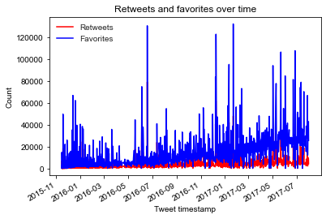

```python
df['retweet_count'].plot(color = 'red', label='Retweets')
df['favorite_count'].plot(color = 'blue', label='Favorites')
plt.style.use('seaborn-darkgrid')
plt.legend(loc='upper left')
plt.xlabel('Tweet timestamp')
plt.ylabel('Count')
plt.title('Retweets and favorites over time')
plt.savefig('retweets_favorites.png')
plt.show()
```

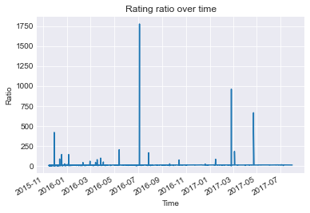

```python
df['rating_numerator'].plot()
plt.style.use('seaborn-darkgrid')
plt.xlabel('Time')
plt.ylabel('Ratio')
plt.title('Rating ratio over time')
plt.savefig('ratio.png')
plt.show()
```